# Proyecto de Minería de datos. Matrimonios de Guatemala

Ayleen Rubio 19003, Andrés Say 19705, Andreé Toledo 18439

25/3/2021

# Proyecto No. 1. Análisis de matrimonios en Guatemala

Actualmente en Guatemala es legal contraer matrimonio hasta cumplir la mayoría de edad, es decir los 18 años, tanto para los hombres como para las mujeres, sin embargo, esto no fue decretado en el Código Civil hasta agosto de 2017. Anteriormente en el 2015 ya se había hecho una reforma para elevar la edad mínima de matrimonio a los 18 años pero en estas reformas aún era posible contraer matrimonio a los 16 años con el permiso de un juez. Antes de todas estas reformas en los Códigos Civil y Penal, era posible contraer matrimonio desde que se cumplía los 14 años de edad y, en caso de agresiones sexuales, era permitido el matrimonio civil entre ofendida y ofensor en relaciones con menores de edad, lo cual cambió en el año 2005 al ser declarado Inconstitucional, posteriormente en el año 2009 La Ley contra la Violencia Sexual, Explotación y Trata de Personas agravó las sentencias en los casos de delitos sexuales con víctimas menores de 18 años. -unionestempranas.org

A pesar de que se haya prohibido contraer matrimonio siendo menores de edad, según una declaración del defensor de la Niñez de la PDH Luis de León en el año 2019, aún se encuentran registros de matrimonio entre dos personas menores, ocurriendo principalmente en departamentos occidentales indígenas de Huehuetenango, Quetzaltenango y San Marcos, además de la capital del país. Según se informó, algunas instituciones públicas y juristas no tenían conocimientos sobre tal prohibición, razón por la cual tuvieron lugar estos matrimonios sin algún tipo de dificultad. -Prensa Libre: redacción AFP, 2019.

En la presente investigación se busca estudiar los casos de matrimonio desde el año 2009 hasta el año 2019 para verificar si existe algún cambio en la ocurrencia de matrimonios a partir de los años de las reformas y para estudiar los casos de matrimonios con menores de edad y verificar si estos suelen ser con otras personas menores de edad o con mayores de edad, de ser el caso, se busca estudiar a su vez la diferencia de edad entre ambos cónyuges.

## Análisis exploratorio

Para poder hacer un análisis exploratorio de los datos de 2009 a 2019 ha sido necesario hacer una limpieza de estos en los siguientes aspectos: Principalmente se cuenta con las columnas que describen departamento de registro, municipio de registro, mes de registro, año de registro, clase de unión, número de nupcias contraídas por el hombre y por la mujer, edad del hombre y de la mujer, grupo étnico del hombre y de la mujer, nacionalidad del hombre y de la mujer, ocupación del hombre y de la mujer, escolaridad del hombre y de la mujer, área geográfica de ocurrencia y día de ocurrencia. Sin embargo, no todos estos datos se encontraban en todas las bases de datos o no contaban con el mismo nombre de variable o se encontraban con diferencias entre mayúsculas y minúsculas, de la misma manera se encontró que en algunos casos el año de ocurrencia se encontraba descrito únicamente como 9 o 10 en vez de contar con el año completo, por lo que fue necesario hacer cambios para generalizar todo. Como estándar se han utilizado los años 2015, 2016 y 2017, por lo que las bases de los años anteriores se han adaptado al formato de estas tres, agregando las columnas de número de nupcias del hombre y la mujer en los años 2010, 2011, 2012, 2013 y 2014, año de ocurrencia en 2012, 2013 y 2014, escolaridad del hombre y de la mujer y día de ocurrencia en el año 2009 y por último se ha agregamo la columna de área geográfica de ocurrencia en los años 2018 y 2019. Luego de agregar estar columnas se ha hecho las modificaciones necesarias en el formato de los datos o respectivos nombres de las columnas para que todos los años contaran con el mismo formato y pudieran ser unificados en una sola base de datos.

[output not shown]

[output not shown]

## Informe de análisis exploratorio

En este informe usted podrá leer los hallazgos sobre los matrimonios, basado en los datos obtenidos del INE

```
##             DEPREG                    MUPREG             MESREG
##  Guatemala     :172623   Guatemala       : 87005   Diciembre: 83457
##  Huehuetenango : 63131   Villa Nueva     : 15316   Enero    : 76874
##  Alta Verapaz  : 57971   Quetzaltenango  : 12272   Marzo    : 74823
##  San Marcos    : 54984   Mixco           : 11904   Mayo     : 74794
##  Quiche        : 53302   Cobán           : 10906   Noviembre: 70123
##  Quetzaltenango: 50457   San Pedro Carchá: 10657   Abril    : 69336
##  (Other)       :377637   (Other)         :682045   (Other)  :380698
##      AÑOREG                          CLAUNI          EDADHOM
##  Min.   :2009   Matrimonio              : 62104   Min.   : 1.00
##  1st Qu.:2012   Unión de hecho          :     0   1st Qu.: 7.00
##  Median :2014   Comunidad absoluta      : 44066   Median :11.00
##  Mean   :2014   Separación absoluta     : 15044   Mean   :14.47
##  3rd Qu.:2017   Comunidad de gananciales:672119   3rd Qu.:17.00
##  Max.   :2020   No especificado         : 36772   Max.   :89.00
##
##     EDADMUJ              GETHOM               GETMUJ
##  Min.   : 1.00   Ignorado   : 69966   Ignorado   : 77158
##  1st Qu.: 7.00   Indigena   :101309   Indigena   : 98014
##  Median :10.00   No indigena:126492   No indigena:122595
##  Mean   :13.45   NA's       :532338   NA's       :532338
##  3rd Qu.:16.00
##  Max.   :92.00
##
##                        NACHOM                             NACMUJ
##  Guatemala                :822684   Guatemala                :821778
##  Estados Unidos de América:  1868   Estados Unidos de América:  1987
##  México                   :  1543   México                   :  1603
##  El Salvador              :   999   El Salvador              :  1591
##  Nicaragua                :   487   Honduras                 :   797
##  Honduras                 :   359   Nicaragua                :   653
##  (Other)                  :  2165   (Other)                  :  1696
##                                                                                           CIUOHOM
##  Peones agropecuarios, pesqueros y forestales                                                 :121065
##  No especificado en otro grupo                                                                :116574
##  Agricultores y trabajadores calificados de cultivos extensivos                               :103076
##  Agricultores y trabajadores calificados de explotaciones agropecuarias con destino al mercado: 77926
##  Estudiante                                                                                   : 73917
##  Vendedores                                                                                   : 42023
##  (Other)                                                                                      :295524
```

[output cut: 17 more lines]

```
##  Length:830105      Urbano  :487340   Length:830105      Length:830105
##  Class :character   Rural   : 67815   Class :character   Class :character
##  Mode  :character   Ignorado:123238   Mode  :character   Mode  :character
##                     3       :     1
##                     11      :     3
##                     None    :151705
##                     NA's    :     3
##     DIAOCU
##  Length:830105
##  Class :character
##  Mode  :character
##
##
##
##
```

A continuación la explicación de qué representa cada una de las variables: DEPREG: departamento de registro MUPREG: municipio de registro MESREG: mes de registro AÑOREG: año de registro CLAUNI: clase de unión EDADHOM: edad del hombre EDADMUJ: edad de la mujer GETHOM: etnia del hombre GETMUJ: etnia de la mujer NACHOM: nacionalidad del hombre NACMUJ: nacionalidad de la mujer CIUOHOM: ocupación del hombre CIUOMUJ: ocupación de la mujer NUNUHO: número de nupcias del hombre NUNUMU: número de nupcias de la mujer DEPOCU: departamento de ocurrencia MUPOCU: municipio de ocurrencia MESOCU: mes de ocurrencia AÑOOCU: año de ocurrencia AREAGOCU: área geográfica de ocurrencia ESCHOM: escolaridad del hombre ESCMUJ: escolaridad de la mujer

En el siguiente cuadro se muestra el tipo de dato de cada una de las variables mencionadas anteriormente:

```
## 'data.frame':    830105 obs. of  23 variables:
##  $ DEPREG  : Factor w/ 24 levels "Guatemala","El Progreso",..: 12 11 13 14 14 13 14 14 4 17 ...
##  $ MUPREG  : Factor w/ 337 levels "Guatemala","Santa Catarina Pinula",..: 167 156 193 233 233 198 237 237 50 277 ...
##  $ MESREG  : Factor w/ 12 levels "Enero","Febrero",..: 4 5 1 8 10 6 10 12 8 8 ...
##  $ AÑOREG  : num  2010 2009 2010 2009 2009 ...
##  $ CLAUNI  : Factor w/ 6 levels "Matrimonio","Unión de hecho",..: 1 1 1 1 1 1 1 1 1 1 ...
##  $ EDADHOM : num  1 1 1 1 1 1 1 1 1 1 ...
##  $ EDADMUJ : num  1 1 1 1 1 1 1 1 1 1 ...
##  $ GETHOM  : Factor w/ 3 levels "Ignorado","Indigena",..: 2 1 1 2 2 1 2 2 2 2 ...
##  $ GETMUJ  : Factor w/ 3 levels "Ignorado","Indigena",..: 2 1 1 2 2 1 2 2 2 3 ...
##  $ NACHOM  : Factor w/ 123 levels "Canadá","Estados Unidos de América",..: 41 41 41 41 41 41 41 41 41 41 ...
##  $ NACMUJ  : Factor w/ 115 levels "Canadá","Estados Unidos de América",..: 35 35 35 35 35 35 35 35 35 35 ...
##  $ CIUOHOM : Factor w/ 489 levels "Oficiales de las fuerzas armadas",..: 12 284 284 284 284 284 284 284 284 284 ...
##  $ CIUOMUJ : Factor w/ 487 levels "Oficiales de las fuerzas armadas",..: 33 440 440 440 440 440 440 440 440 440 ...
##  $ NUNUHO  : Factor w/ 8 levels "1","2","3","5",..: 6 6 1 1 1 6 6 6 6 6 ...
##  $ NUNUMU  : Factor w/ 8 levels "1","2","3","5",..: 6 6 1 1 1 6 6 6 6 6 ...
##  $ DEPOCU  : Factor w/ 22 levels "Alta Verapaz",..: 17 15 8 14 14 8 14 14 3 12 ...
##  $ MUPOCU  : Factor w/ 348 levels "Guatemala","Santa Catarina Pinula",..: 167 156 193 233 233 198 237 237 50 277 ...
##  $ MESOCU  : Factor w/ 12 levels "Enero","Febrero",..: 9 3 12 7 10 6 9 11 7 8 ...
##  $ AÑOOCU  : chr  "2009" "2009" "2009" "2009" ...
##  $ AREAGOCU: Factor w/ 6 levels "Urbano","Rural",..: 3 3 3 3 3 3 3 3 3 3 ...
##  $ ESCHOM  : chr  "Ignorado" "Ignorado" "Ignorado" "Ignorado" ...
##  $ ESCMUJ  : chr  "Ignorado" "Ignorado" "Ignorado" "Ignorado" ...
##  $ DIAOCU  : chr  "Ignorado" "Ignorado" "Ignorado" "Ignorado" ...
```

Las variables más interesantes para el porpósito de la investigación son las que proporcionan información de la fecha del matrimonio. Otras con gran potencial son las edades de los cónyuges, ya que con ellas podemos analizar cual es la tendencia de matrimonios de menores, diferencias de edades etc.

## Análisis de variables cuantitativas

### Registros de matrimonio

#### Prueba de normalidad para registros de matrimonios:

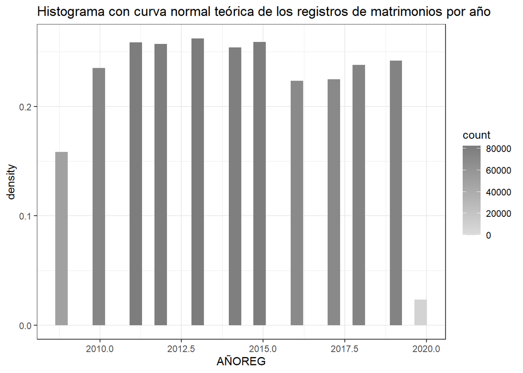

Como es de esperarse, no es posible observar que exista una relación en el histograma de registros de matrimonios con las reformas planteadas para la prohibición de matrimonios con menores de edad, ya que parece que la cantidad de matrimonios ha sido bastante constante durante los años. Según el histograma mostrado, la cantidad de matrimonios por año no sigue una distribución normal.

### Diagrama de caja y bigotes

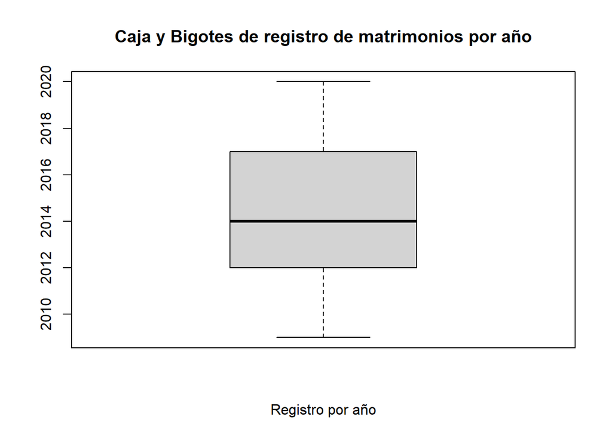

### Diagrama de qqnormal

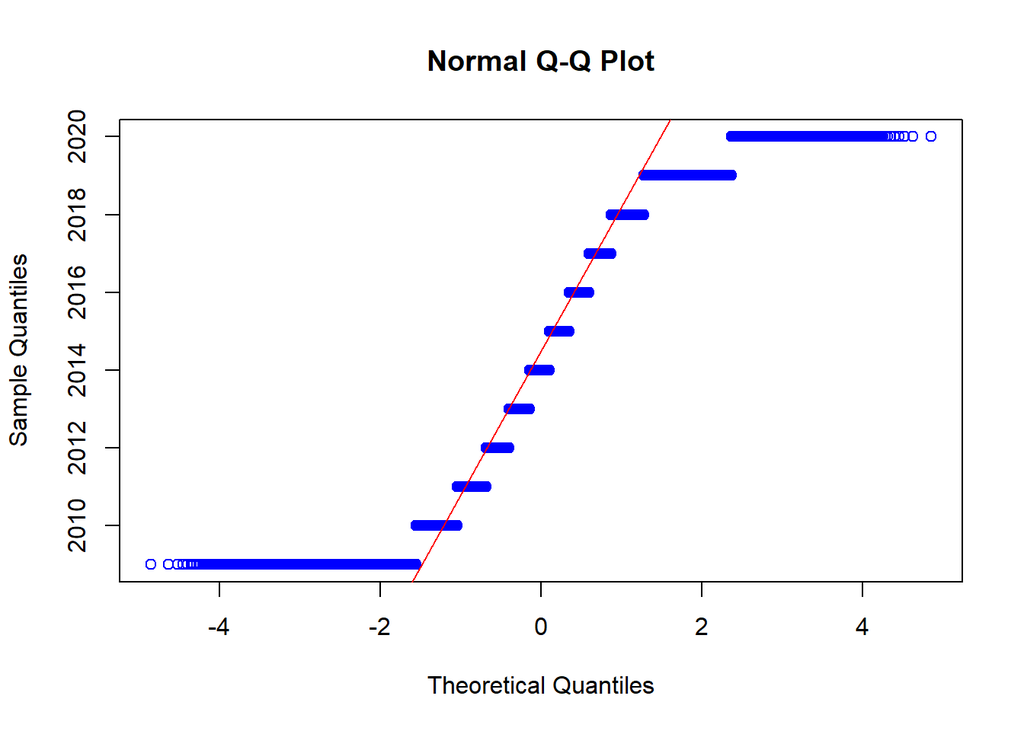

Aunque en el diagrama qqnormal parece que se sigue una distribución normal al encontrarse muchos de los datos alineados, hay bastantes datos que se encuentran fuera de la linea de tendencia, por lo que no se cumple con normalidad en la cantidad de matrimonios por año.

En conclusión, la cantidad de matrimonios por año no sigue una distribución normal.

## Registros de Edad hombre

### Prueba de normalidad para la edad del hombre:

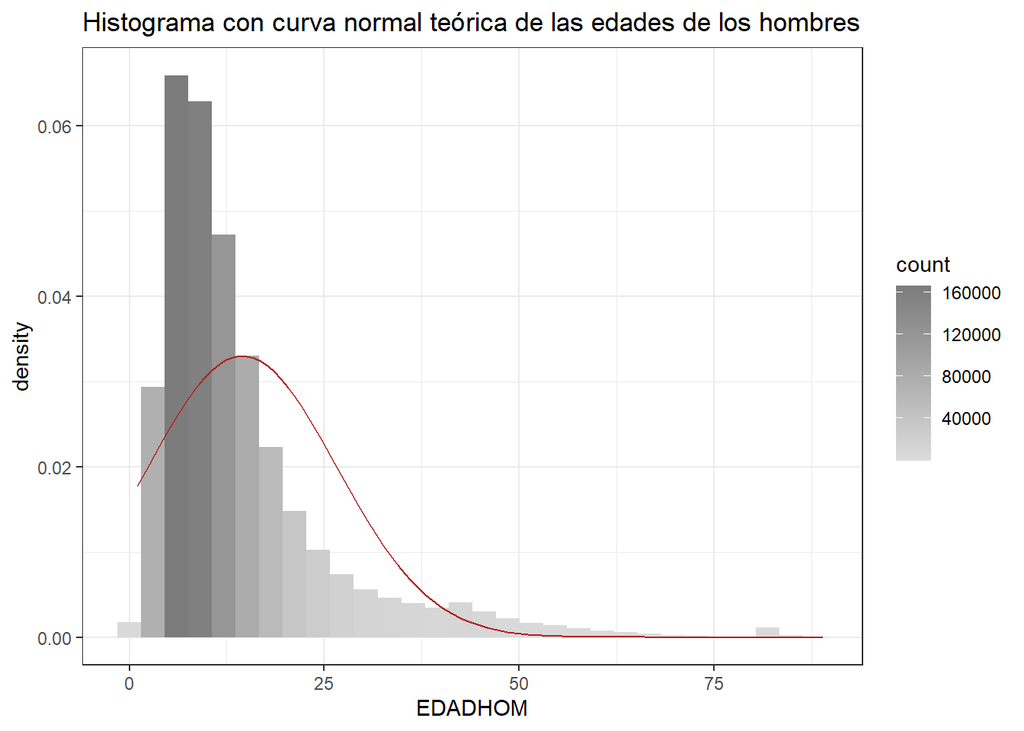

### Diagrama de caja y bigotes

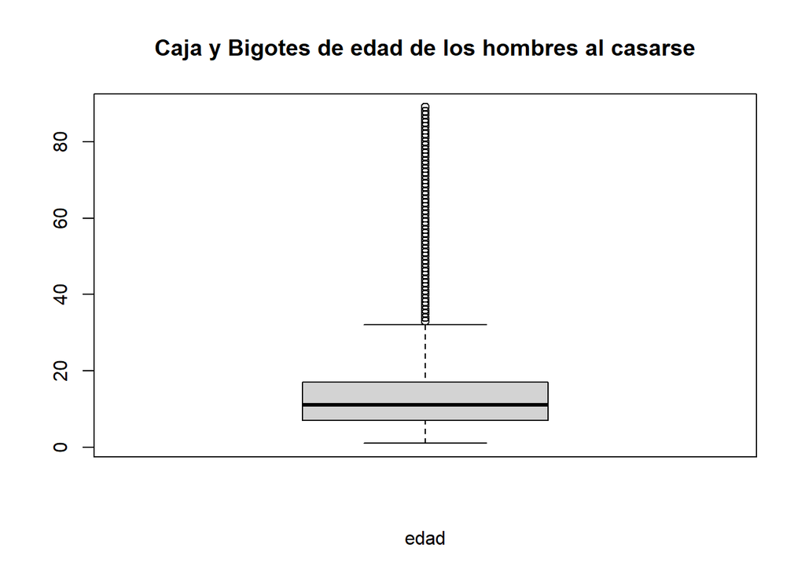

Se evidencia la gran cantidad de datos atípicos en el diagrama, se encuentran muy dispersos arriba de la media y del extremo superior que se encuentra al rededor de los 30 años. Esto quiere decir que la edad de los hombres en el matrimonio no sigue una distribución normal.

### Diagrama qqnormal

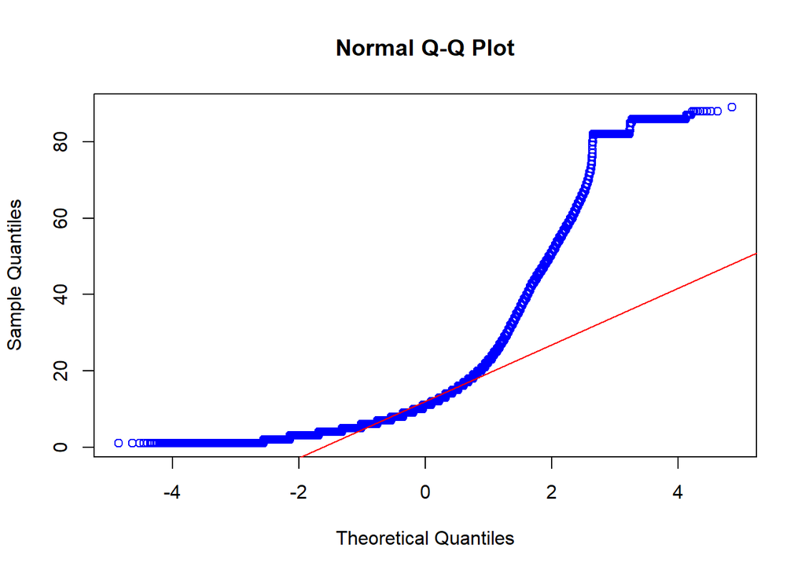

Como puede observarse, es muy notable en el diagrama qqnormal que los datos no siguen una distribución acorde a la linea de tendencia, esto quiere decir que la edad del hombre en el matrimonio no sigue una distribución normal.

En conclusión, la edad de los hombres en el matrimonio no sigue una distribución normal.

## Registros de edad de mujeres

### Prueba de normalidad para la edad de la mujer:

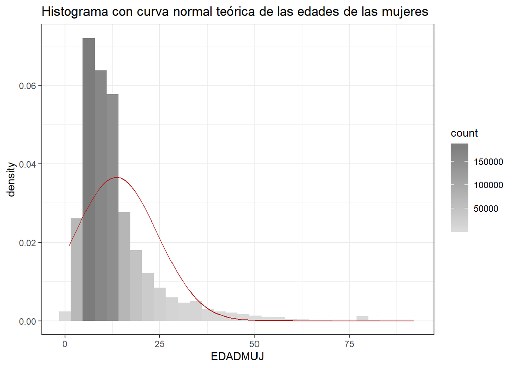

### Diagrama de caja y bigotes

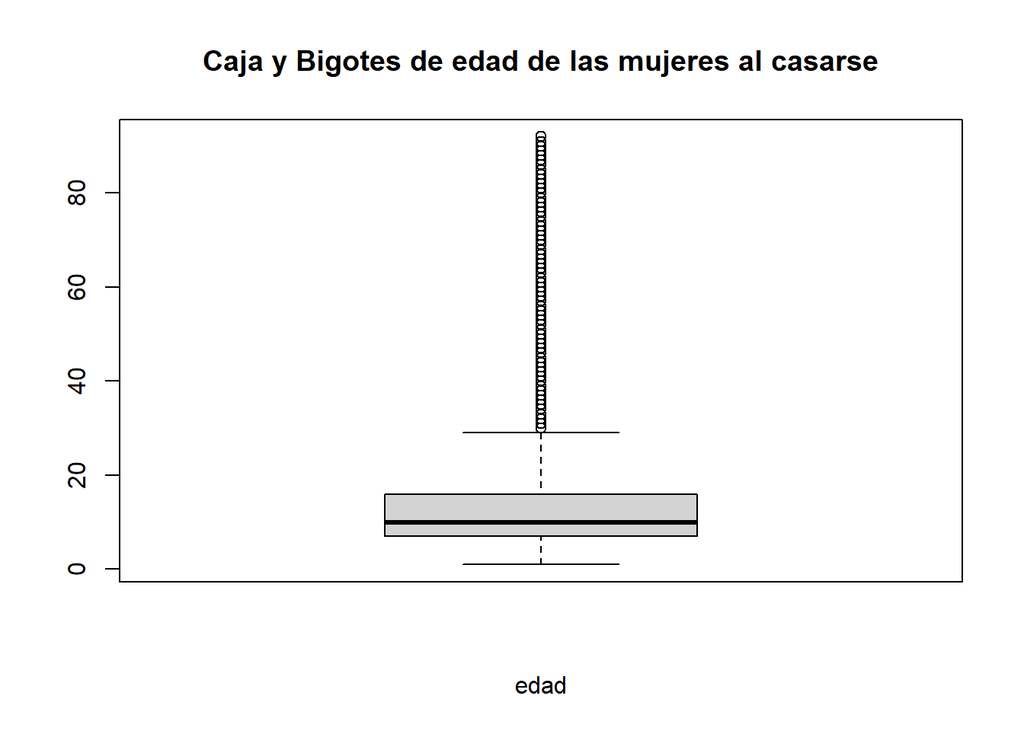

En este diagrama de caja y bigotes es posible ver una gran cantidad de datos atípicos arriba del extremo superior que se encuentra al rededor de los 30 años, muy similar al diagrama de la edad de los hombres, por lo que de la misma manera no se cuenta con normalidad en la edad de las mujeres en el matrimonio.

### Diagrama qqnormal

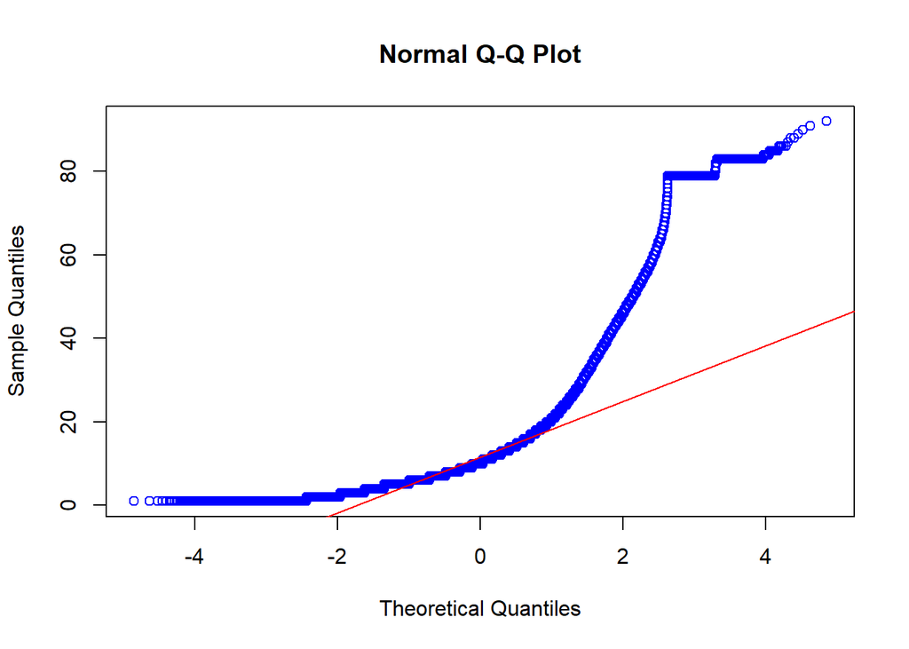

Como puede observarse, los valores en este diagrama evidentemente no siguen con una distribución normal ya que no esán sobre la linea de tendencia, por lo que la edad de las mujeres en el matrimonio no sigue una distribución normal.

En conclusión, la edad de las mujeres en el matrimonio no sigue una distribución normal.

## Tabla de frecuencias para variables cualitativas

### Tabla de frecuencias para el departamento de ocurrencia y representación gráfica

```
##
##   Alta Verapaz   Baja Verapaz  Chimaltenango     Chiquimula    El Progreso
##          58011          15752          41224          18968           9553
##      Escuintla      Guatemala  Huehuetenango         Izabal         Jalapa
##          40117         169944          63128          18851          16303
##        Jutiapa          Peten Quetzaltenango         Quiche     Retalhuleu
##          26970          24994          50267          53208          21188
##   Sacatepequez     San Marcos     Santa Rosa         Solola  Suchitepequez
##          23698          54807          20129          22668          37426
##    Totonicapan         Zacapa
##          29428          13471
```

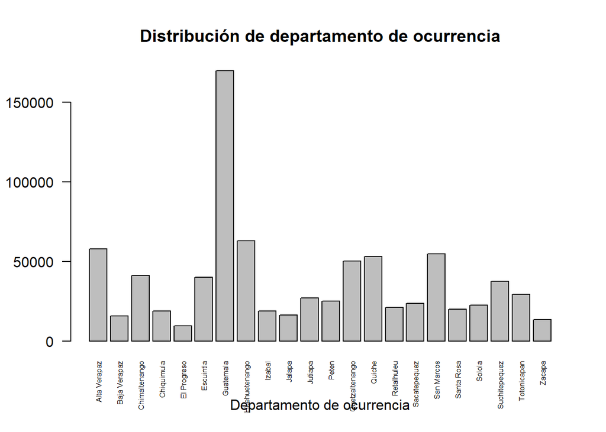

Como puede observarse, el departamento en el que suele haber más matrimonios es en Guatemala, seguido por Huehuetenango y luego por Alta Verapaz.

### Tabla de frecuencias para el municipio de ocurrencia

```
##
##                   Guatemala       Santa Catarina Pinula
##                       70183                        3797
##             San José Pinula          San José del Golfo
##                        4751                        1117
##                    Palencia                   Chinautla
##                        3234                        4758
##           San Pedro Ayampuc                       Mixco
##                        2629                       19566
##      San Pedro Sacatepéquez       San Juan Sacatepéquez
##                        8561                       12109
##                San Raymundo                 Chuarrancho
##                        2295                        1034
##                   Fraijanes                   Amatitlán
##                        2492                        7371
##                 Villa Nueva               Villa Canales
##                       17955                        7992
##                      Petapa                  Guastatoya
##                        5455                        1977
##                     Morazán   San Agustín Acasaguastlán
##                         655                        1963
## San Cristóbal Acasaguastlán                   El Jícaro
##                         339                         699
##                     Sansare                    Sanarate
##                         695                        2382
##          San Antonio la Paz           Antigua Guatemala
##                         843                        4687
##                 Jocotenango                    Pastores
##                        1096                         922
##                    Sumpango       Santo Domingo Xenacoj
##                        2524                         635
##       Santiago Sacatepéquez  San Bartolomé Milpas Altas
##                        2231                         482
##      San Lucas Sacatepéquez    Santa Lucía Milpas Altas
##                        2131                        1321
##      Magdalena Milpas Altas        Santa María de Jesús
##                         721                        1413
##                Ciudad Vieja           San Miguel Dueñas
##                        2122                         764
##                  Alotenango San Antonio Aguas Calientes
```

[output cut: 294 more lines]

```
##                         394                         217
##                        01-1                        08-1
##                           5                           1
##                        09-1                        12-1
##                           1                           2
##                    Sipacate         San José la Maquina
##                          91                         831
##                     Petatán                        03-1
##                         103                           1
##                        05-1                        06-1
##                           1                           1
##                        07-1                        0928
##                           1                           2
##                        11-1                        13-1
##                           1                           1
```

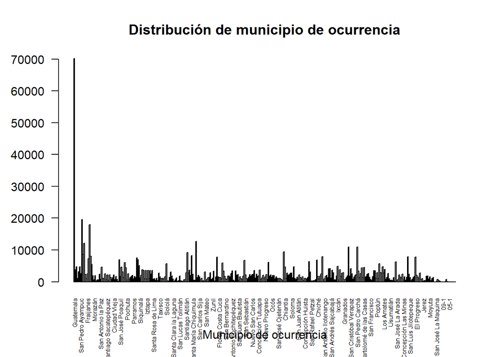

De la misma manera, es Guatemala el municipio que cuenta con la mayor cantidad de matrimonios.

### Tabla de frecuencias para la escolaridad del hombre

```
##
##        Básico Diversificado      Ignorado       Ninguno      Primaria
##        120498        189650        115327        119964        255480
## Universitario
##         29186
```

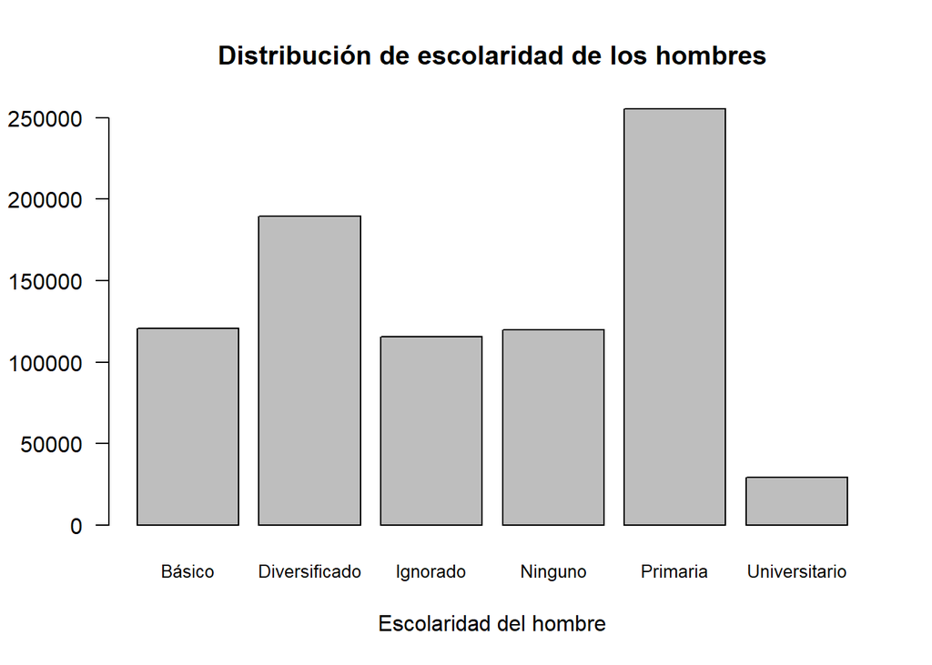

### Tabla de frecuencias para la escolaridad de la Mujer

```
##
##        Básico Diversificado      Ignorado       Ninguno      Primaria
##         98827        183340        130464        170223        222076
## Universitario
##         25175
```

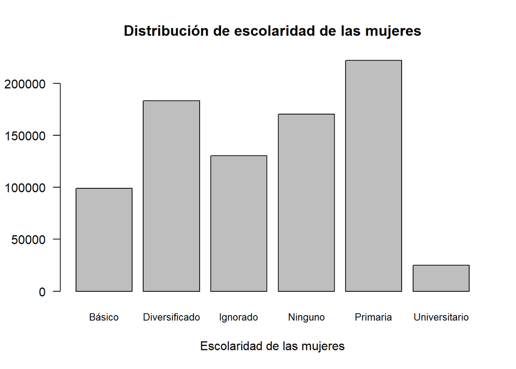

### Tabla de frecuencias para el grupo étnico del hombre

```
##
##    Ignorado    Indigena No indigena
##       69966      101309      126492
```

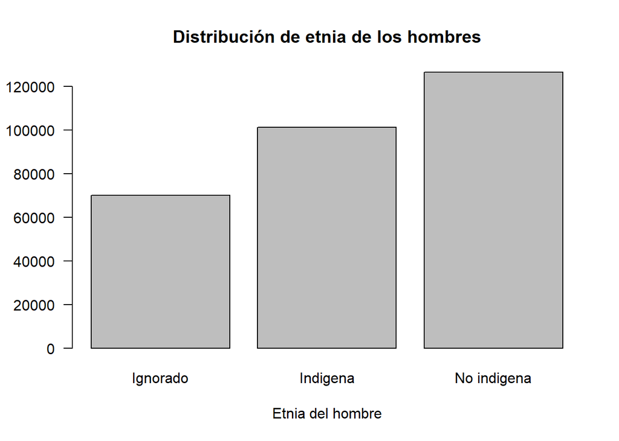

Coomo puede observarse, el grupo étnico más común al que pertenecen los hombres en la base de datos es no indígena.

### Tabla de frecuencias para el grupo étnico de la mujer

```
##
##    Ignorado    Indigena No indigena
##       77158       98014      122595
```

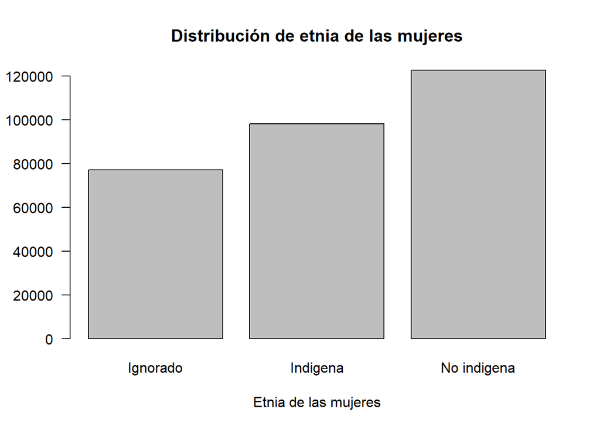

De la misma manera, puede observarse que el grupo étnico más común al que pertenecen las mujeres en la base de datos es no indígena.

## Correlacion entre edades de los cónyuges

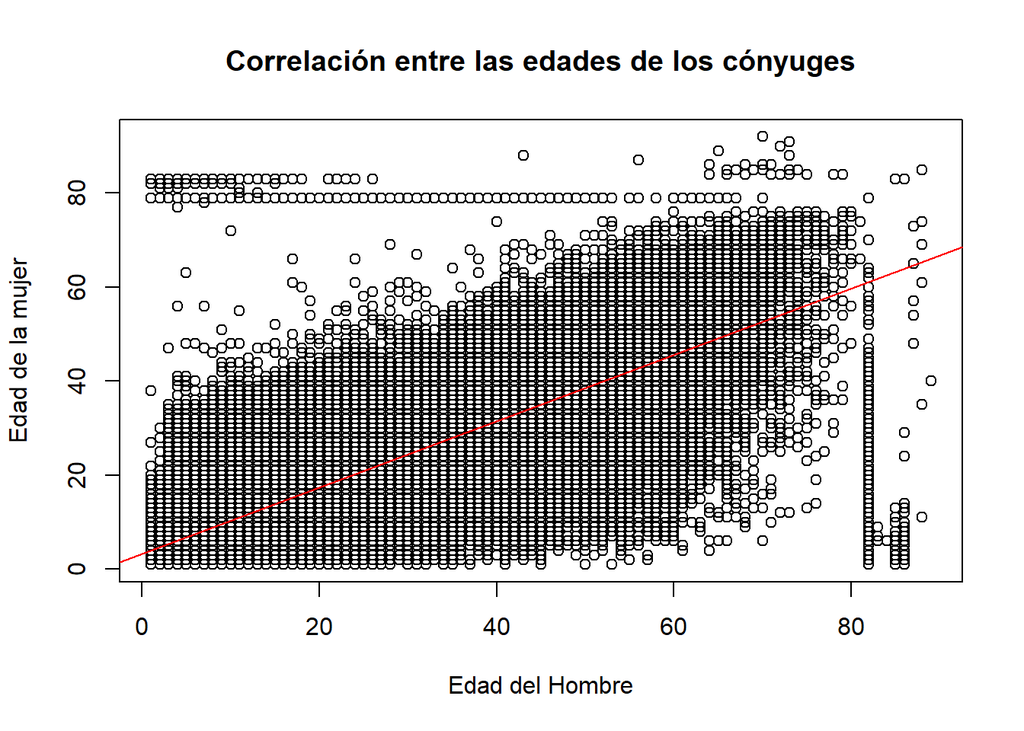

Como se puede ver, existen muchos datos extraños dentro del data set, estudiándolo se ha encontrado una gran cantidad de 1’s y otros datos en donde la edad de los “cónyuges” es incluso menor a 5 años, por lo que la presencia de estos datos nos ha llevado a buscar la naturaleza de las variables, por lo que revisando la lista de variables del INE de cada año, pudimos darnos cuenta que la edad más pequeña para mujeres durante los años fue 12 y de los hombres 14, por lo tanto se hizo un nuevo dataset para estudiar con precisión lo que deseamos estudiar. Se ha filtrado de la base de datos de matrimonios los valores en donde la edad de la mujer era menor a 18 (por el objetivo) y mayor a 12 años (para eliminar los datos no significativos o no lógicos), asimismo se filtró los datos en donde el hombre es menor a 14 años (de igual manera para eliminar esos datos confusos).

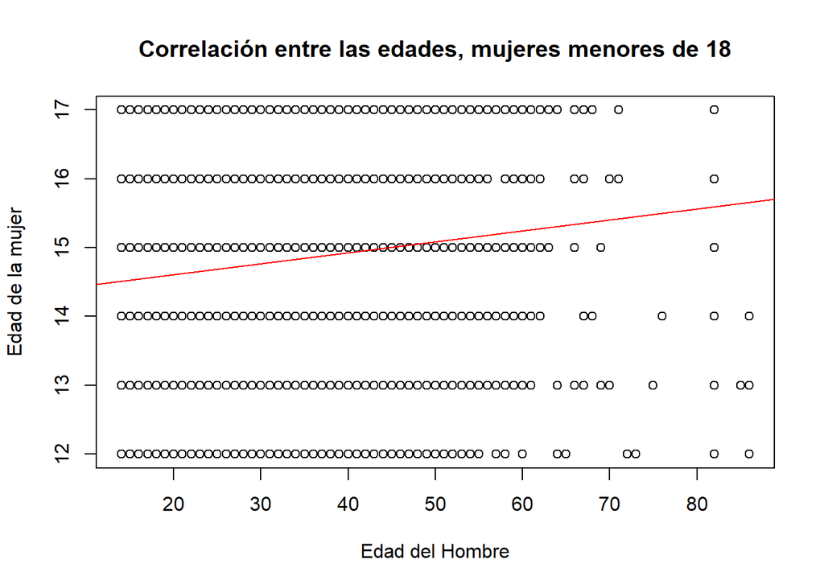

Filtrando los datos en donde las mujeres son menores a 18 años, es posible observar que una gran cantidad de mujeres se encuentran comprometidas con hombres mucho mayores a ellas, existen datos atípicos muy extensos y preocupantes, cabe mencionar que los datos que se encuentran en el fondo (muy pocos pero si existen) se encuentran así debido a que los datos no son indicados en el diagrama.

## Departamentos en donde se llevan a cabo los matrimonios de mujeres menores de edad

```
##
##   Alta Verapaz   Baja Verapaz  Chimaltenango     Chiquimula    El Progreso
##           2531            512           1314           1038            555
##      Escuintla      Guatemala  Huehuetenango         Izabal         Jalapa
##           2018           9408           2532           1304            966
##        Jutiapa          Peten Quetzaltenango         Quiche     Retalhuleu
##           1718           1598           1936           1891            820
##   Sacatepequez     San Marcos     Santa Rosa         Solola  Suchitepequez
##           1150           2194           1221            865           1321
##    Totonicapan         Zacapa
##            885            880
```

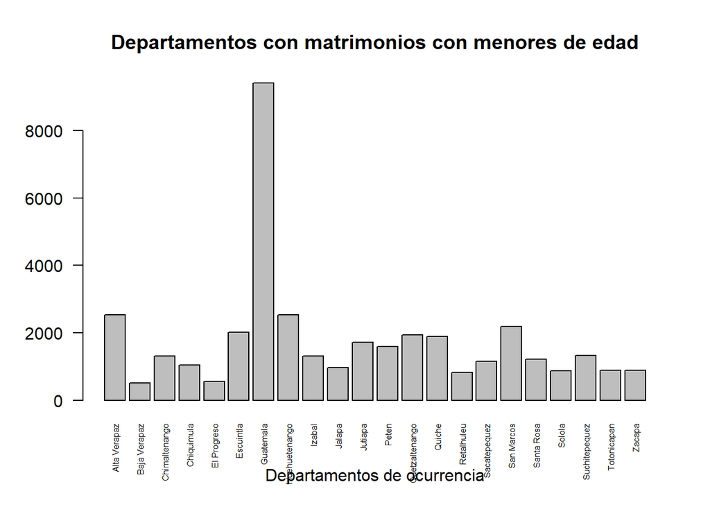

Puede observarse que muchos de estos matrimonios se llevan a cabo en el departamento de Guatemala, donde una gran población son ladinos.

## Municipios en donde se llevan a cabo los matrimonios de mujeres menores de edad

```
## depMun
##                   Guatemala       Santa Catarina Pinula
##                        4565                         226
##             San José Pinula          San José del Golfo
##                         233                          67
##                    Palencia                   Chinautla
##                         145                         200
##           San Pedro Ayampuc                       Mixco
##                         113                        1116
##      San Pedro Sacatepéquez       San Juan Sacatepéquez
##                         288                         452
##                San Raymundo                 Chuarrancho
##                          76                          44
##                   Fraijanes                   Amatitlán
##                         145                         338
##                 Villa Nueva               Villa Canales
##                         938                         357
##                      Petapa                  Guastatoya
##                         286                         115
##                     Morazán   San Agustín Acasaguastlán
##                          42                          95
## San Cristóbal Acasaguastlán                   El Jícaro
##                          21                          42
##                     Sansare                    Sanarate
##                          47                         139
##          San Antonio la Paz           Antigua Guatemala
##                          54                         363
##                 Jocotenango                    Pastores
##                          54                          36
##                    Sumpango       Santo Domingo Xenacoj
##                          94                          28
##       Santiago Sacatepéquez  San Bartolomé Milpas Altas
##                          79                          29
##      San Lucas Sacatepéquez    Santa Lucía Milpas Altas
##                         144                          79
##      Magdalena Milpas Altas        Santa María de Jesús
##                          25                          45
##                Ciudad Vieja           San Miguel Dueñas
##                          65                          27
##                  Alotenango San Antonio Aguas Calientes
```

[output cut: 294 more lines]

```
##                          29                          13
##                        01-1                        08-1
##                           0                           0
##                        09-1                        12-1
##                           0                           0
##                    Sipacate         San José la Maquina
##                           8                          43
##                     Petatán                        03-1
##                           1                           0
##                        05-1                        06-1
##                           0                           0
##                        07-1                        0928
##                           0                           0
##                        11-1                        13-1
##                           0                           0
```

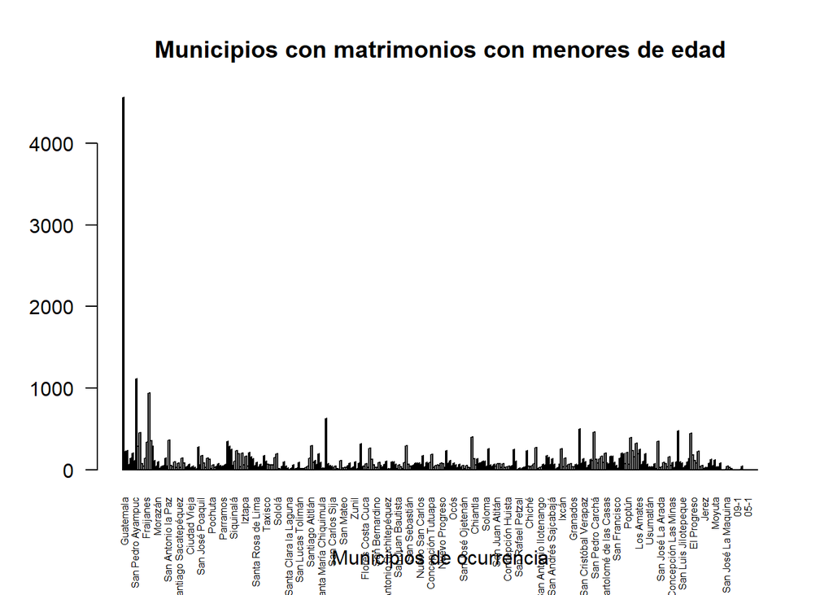

De la misma manera, puede observarse que la mayor cantidad de ocurrencias se encuentra en Guatemala.

## La etnia de la mujer en donde es más común este evento

```
## etniaMujer
##    Ignorado    Indigena No indigena
##        3114        3229        5951
```

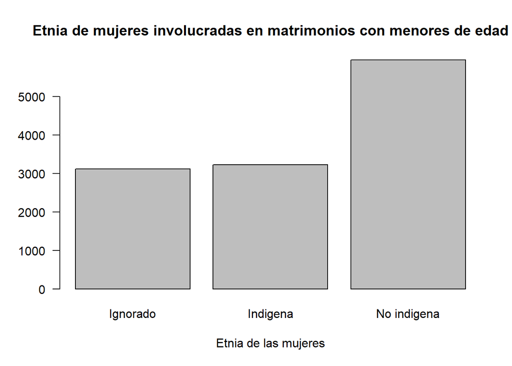

## La etnia del hombre en donde es más común este evento

```
## etniaHombre
##    Ignorado    Indigena No indigena
##        3251        3127        5916
```

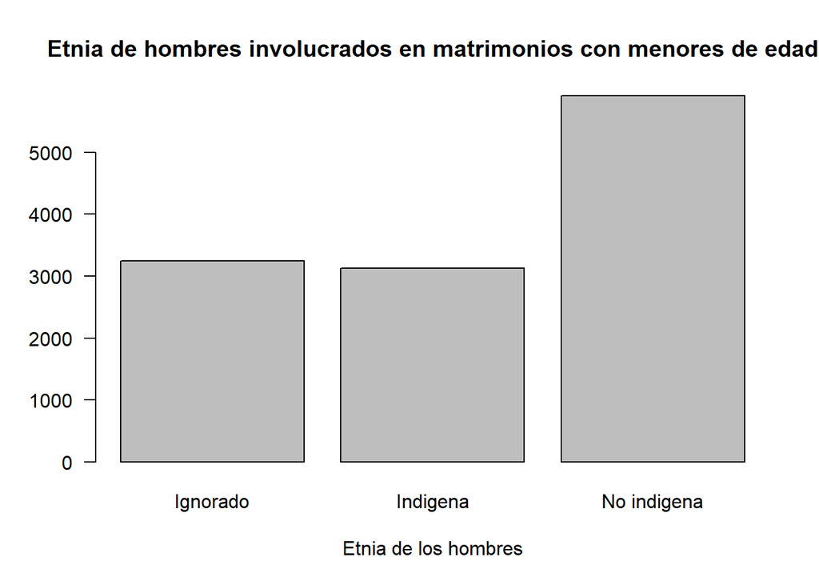

# ———————————–Clustering——————————–

```
##      AÑOREG        EDADHOM         EDADMUJ          AÑOOCU
##  Min.   :2009   Min.   :14.00   Min.   :12.00   Min.   :1.000
##  1st Qu.:2012   1st Qu.:15.00   1st Qu.:13.00   1st Qu.:4.000
##  Median :2015   Median :17.00   Median :15.00   Median :6.000
##  Mean   :2014   Mean   :18.81   Mean   :14.59   Mean   :5.976
##  3rd Qu.:2017   3rd Qu.:20.00   3rd Qu.:16.00   3rd Qu.:9.000
##  Max.   :2020   Max.   :86.00   Max.   :17.00   Max.   :9.000
```

Se trabajará con las siguientes variables que tienen formato int para formas grupos: AÑOREG, ALOOCU, EDADHOM,EDADMUJ. Esto debido a que son variables que se pueden clasificar por grupos y los resultados pueden ser interpretados.

Para saber la mejor cantidad de clusters a utilizar, se hará lo siguiente:

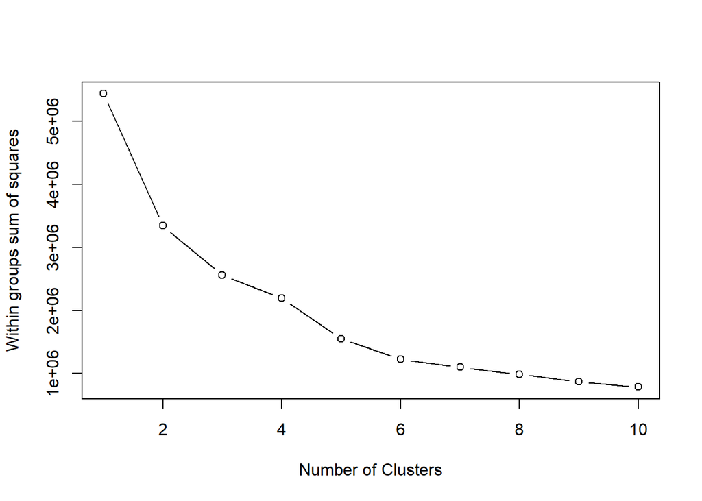

## Agrupamiento por medio de k-means

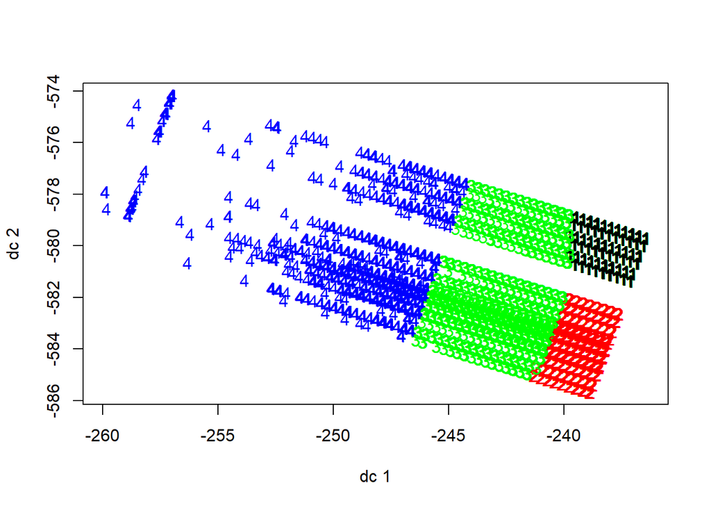

Se puede observar cómo los datos se encuentran divididos en 4 grupos, verde, rojo, azul y negr, en donde todos los grupos, excepto el azul, parecen estar bastante concentrados en un punto.

## Mixture of gaussians

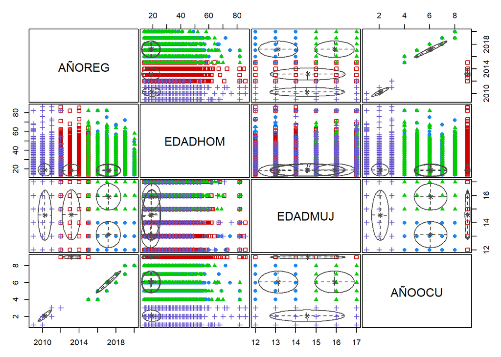

En este gráfico se puede observar como en cada combinación de gráficos sucede la combinación de grupos y se observan los clusters bastante separados y bien identificados.

## Fuzzy C-means

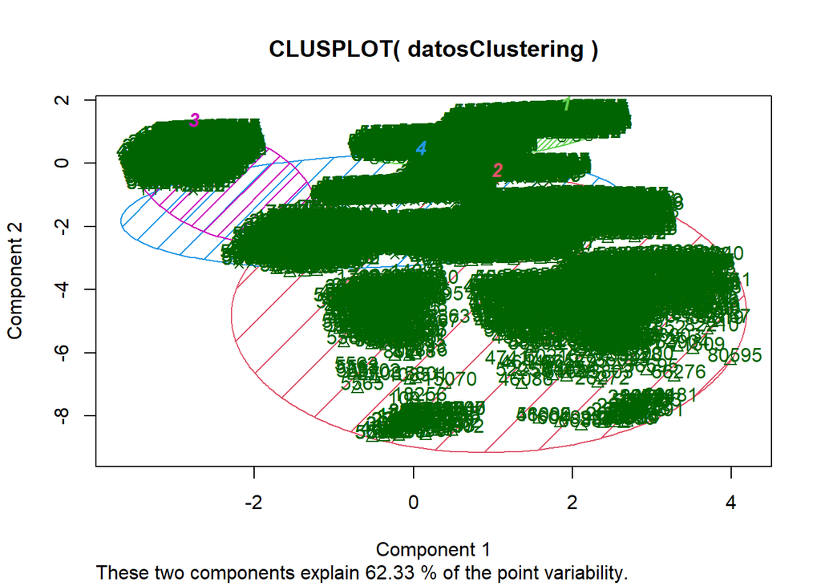

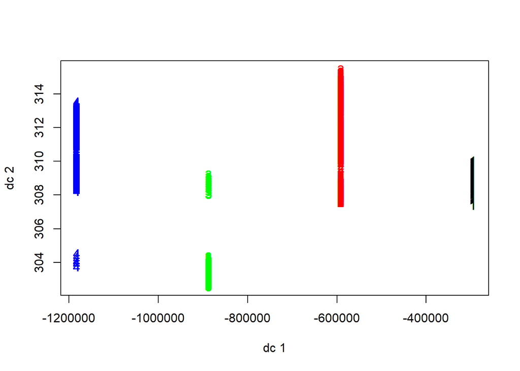

En el segundo gráfico se encuentran ya separados los clusters y es posible observar la variabilidad entre ellos.

```
##      AÑOREG        EDADHOM         EDADMUJ          AÑOOCU         grupo
##  Min.   :2009   Min.   :14.00   Min.   :12.00   Min.   :1.00   Min.   :1
##  1st Qu.:2010   1st Qu.:15.00   1st Qu.:13.00   1st Qu.:1.00   1st Qu.:1
##  Median :2010   Median :16.00   Median :15.00   Median :2.00   Median :1
##  Mean   :2010   Mean   :16.92   Mean   :14.52   Mean   :2.09   Mean   :1
##  3rd Qu.:2011   3rd Qu.:19.00   3rd Qu.:16.00   3rd Qu.:3.00   3rd Qu.:1
##  Max.   :2012   Max.   :24.00   Max.   :17.00   Max.   :3.00   Max.   :1
```

```
##      AÑOREG        EDADHOM         EDADMUJ          AÑOOCU         grupo
##  Min.   :2012   Min.   :14.00   Min.   :12.00   Min.   :4.00   Min.   :2
##  1st Qu.:2014   1st Qu.:15.00   1st Qu.:13.00   1st Qu.:6.00   1st Qu.:2
##  Median :2016   Median :16.00   Median :15.00   Median :7.00   Median :2
##  Mean   :2016   Mean   :16.56   Mean   :14.54   Mean   :7.13   Mean   :2
##  3rd Qu.:2018   3rd Qu.:18.00   3rd Qu.:16.00   3rd Qu.:9.00   3rd Qu.:2
##  Max.   :2020   Max.   :22.00   Max.   :17.00   Max.   :9.00   Max.   :2
```

```
##      AÑOREG        EDADHOM         EDADMUJ          AÑOOCU          grupo
##  Min.   :2009   Min.   :22.00   Min.   :12.00   Min.   :1.000   Min.   :3
##  1st Qu.:2013   1st Qu.:23.00   1st Qu.:13.00   1st Qu.:4.000   1st Qu.:3
##  Median :2015   Median :25.00   Median :15.00   Median :7.000   Median :3
##  Mean   :2015   Mean   :26.61   Mean   :14.84   Mean   :6.329   Mean   :3
##  3rd Qu.:2017   3rd Qu.:29.00   3rd Qu.:16.00   3rd Qu.:9.000   3rd Qu.:3
##  Max.   :2020   Max.   :39.00   Max.   :17.00   Max.   :9.000   Max.   :3
```

```
##      AÑOREG        EDADHOM         EDADMUJ          AÑOOCU         grupo
##  Min.   :2009   Min.   :40.00   Min.   :12.00   Min.   :1.00   Min.   :4
##  1st Qu.:2011   1st Qu.:42.00   1st Qu.:13.00   1st Qu.:3.00   1st Qu.:4
##  Median :2014   Median :47.00   Median :15.00   Median :6.00   Median :4
##  Mean   :2014   Mean   :52.38   Mean   :14.67   Mean   :5.47   Mean   :4
##  3rd Qu.:2016   3rd Qu.:55.00   3rd Qu.:16.00   3rd Qu.:9.00   3rd Qu.:4
##  Max.   :2020   Max.   :86.00   Max.   :17.00   Max.   :9.00   Max.   :4
```

```
##      AÑOREG        EDADHOM         EDADMUJ          AÑOOCU          grupo
##  Min.   :2015   Min.   :14.00   Min.   :12.00   Min.   :4.000   Min.   :2.000
##  1st Qu.:2016   1st Qu.:15.00   1st Qu.:12.00   1st Qu.:5.000   1st Qu.:2.000
##  Median :2017   Median :17.00   Median :13.00   Median :6.000   Median :2.000
##  Mean   :2017   Mean   :18.27   Mean   :13.05   Mean   :6.072   Mean   :2.175
##  3rd Qu.:2018   3rd Qu.:20.00   3rd Qu.:14.00   3rd Qu.:7.000   3rd Qu.:2.000
##  Max.   :2020   Max.   :82.00   Max.   :14.00   Max.   :8.000   Max.   :4.000
##      mxGau
##  Min.   :1
##  1st Qu.:1
##  Median :1
##  Mean   :1
##  3rd Qu.:1
##  Max.   :1
```

```
##      AÑOREG        EDADHOM         EDADMUJ          AÑOOCU      grupo
##  Min.   :2012   Min.   :14.00   Min.   :12.00   Min.   :9   Min.   :2.000
##  1st Qu.:2012   1st Qu.:15.00   1st Qu.:13.00   1st Qu.:9   1st Qu.:2.000
##  Median :2013   Median :17.00   Median :15.00   Median :9   Median :2.000
##  Mean   :2013   Mean   :18.74   Mean   :14.59   Mean   :9   Mean   :2.204
##  3rd Qu.:2014   3rd Qu.:20.00   3rd Qu.:16.00   3rd Qu.:9   3rd Qu.:2.000
##  Max.   :2015   Max.   :86.00   Max.   :17.00   Max.   :9   Max.   :4.000
##      mxGau
##  Min.   :2
##  1st Qu.:2
##  Median :2
##  Mean   :2
##  3rd Qu.:2
##  Max.   :2
```

```
##      AÑOREG        EDADHOM         EDADMUJ          AÑOOCU          grupo
##  Min.   :2015   Min.   :14.00   Min.   :15.00   Min.   :4.000   Min.   :2.000
##  1st Qu.:2016   1st Qu.:15.00   1st Qu.:15.00   1st Qu.:5.000   1st Qu.:2.000
##  Median :2017   Median :17.00   Median :16.00   Median :6.000   Median :2.000
##  Mean   :2017   Mean   :19.04   Mean   :15.99   Mean   :6.075   Mean   :2.222
##  3rd Qu.:2018   3rd Qu.:21.00   3rd Qu.:17.00   3rd Qu.:7.000   3rd Qu.:2.000
##  Max.   :2020   Max.   :82.00   Max.   :17.00   Max.   :8.000   Max.   :4.000
##      mxGau
##  Min.   :3
##  1st Qu.:3
##  Median :3
##  Mean   :3
##  3rd Qu.:3
##  Max.   :3
```

```
##      AÑOREG        EDADHOM         EDADMUJ          AÑOOCU         grupo
##  Min.   :2009   Min.   :14.00   Min.   :12.00   Min.   :1.00   Min.   :1.000
##  1st Qu.:2010   1st Qu.:15.00   1st Qu.:13.00   1st Qu.:1.00   1st Qu.:1.000
##  Median :2010   Median :17.00   Median :15.00   Median :2.00   Median :1.000
##  Mean   :2010   Mean   :19.18   Mean   :14.55   Mean   :2.09   Mean   :1.285
##  3rd Qu.:2011   3rd Qu.:20.00   3rd Qu.:16.00   3rd Qu.:3.00   3rd Qu.:1.000
##  Max.   :2012   Max.   :86.00   Max.   :17.00   Max.   :3.00   Max.   :4.000
##      mxGau
##  Min.   :4
##  1st Qu.:4
##  Median :4
##  Mean   :4
##  3rd Qu.:4
##  Max.   :4
```

```
##      AÑOREG        EDADHOM         EDADMUJ          AÑOOCU          grupo
##  Min.   :2012   Min.   :14.00   Min.   :12.00   Min.   :4.000   Min.   :2
##  1st Qu.:2014   1st Qu.:14.00   1st Qu.:13.00   1st Qu.:6.000   1st Qu.:2
##  Median :2016   Median :16.00   Median :14.00   Median :7.000   Median :2
##  Mean   :2016   Mean   :15.69   Mean   :14.45   Mean   :7.095   Mean   :2
##  3rd Qu.:2018   3rd Qu.:17.00   3rd Qu.:16.00   3rd Qu.:9.000   3rd Qu.:2
##  Max.   :2020   Max.   :19.00   Max.   :17.00   Max.   :9.000   Max.   :2
##      mxGau          FCGrupos
##  Min.   :1.000   Min.   :1
##  1st Qu.:1.000   1st Qu.:1
##  Median :2.000   Median :1
##  Mean   :1.992   Mean   :1
##  3rd Qu.:3.000   3rd Qu.:1
##  Max.   :3.000   Max.   :1
```

```
##      AÑOREG        EDADHOM         EDADMUJ          AÑOOCU          grupo
##  Min.   :2009   Min.   :30.00   Min.   :12.00   Min.   :1.000   Min.   :3.000
##  1st Qu.:2012   1st Qu.:32.00   1st Qu.:13.00   1st Qu.:3.000   1st Qu.:3.000
##  Median :2014   Median :35.00   Median :15.00   Median :6.000   Median :3.000
##  Mean   :2014   Mean   :39.52   Mean   :14.73   Mean   :5.816   Mean   :3.322
##  3rd Qu.:2017   3rd Qu.:42.00   3rd Qu.:16.00   3rd Qu.:9.000   3rd Qu.:4.000
##  Max.   :2020   Max.   :86.00   Max.   :17.00   Max.   :9.000   Max.   :4.000
##      mxGau          FCGrupos
##  Min.   :1.000   Min.   :2
##  1st Qu.:2.000   1st Qu.:2
##  Median :3.000   Median :2
##  Mean   :2.564   Mean   :2
##  3rd Qu.:4.000   3rd Qu.:2
##  Max.   :4.000   Max.   :2
```

```
##      AÑOREG        EDADHOM      EDADMUJ          AÑOOCU          grupo
##  Min.   :2009   Min.   :14   Min.   :12.00   Min.   :1.000   Min.   :1.00
##  1st Qu.:2010   1st Qu.:15   1st Qu.:13.00   1st Qu.:1.000   1st Qu.:1.00
##  Median :2010   Median :16   Median :15.00   Median :2.000   Median :1.00
##  Mean   :2010   Mean   :17   Mean   :14.53   Mean   :2.073   Mean   :1.03
##  3rd Qu.:2011   3rd Qu.:19   3rd Qu.:16.00   3rd Qu.:3.000   3rd Qu.:1.00
##  Max.   :2012   Max.   :27   Max.   :17.00   Max.   :3.000   Max.   :3.00
##      mxGau      FCGrupos
##  Min.   :4   Min.   :3
##  1st Qu.:4   1st Qu.:3
##  Median :4   Median :3
##  Mean   :4   Mean   :3
##  3rd Qu.:4   3rd Qu.:3
##  Max.   :4   Max.   :3
```

```
##      AÑOREG        EDADHOM         EDADMUJ          AÑOOCU         grupo
##  Min.   :2009   Min.   :18.00   Min.   :12.00   Min.   :1.00   Min.   :1.00
##  1st Qu.:2013   1st Qu.:20.00   1st Qu.:13.00   1st Qu.:5.00   1st Qu.:2.00
##  Median :2015   Median :21.00   Median :15.00   Median :7.00   Median :2.00
##  Mean   :2015   Mean   :22.03   Mean   :14.87   Mean   :6.91   Mean   :2.46
##  3rd Qu.:2017   3rd Qu.:24.00   3rd Qu.:16.00   3rd Qu.:9.00   3rd Qu.:3.00
##  Max.   :2020   Max.   :29.00   Max.   :17.00   Max.   :9.00   Max.   :3.00
##      mxGau          FCGrupos
##  Min.   :1.000   Min.   :4
##  1st Qu.:2.000   1st Qu.:4
##  Median :2.000   Median :4
##  Mean   :2.227   Mean   :4
##  3rd Qu.:3.000   3rd Qu.:4
##  Max.   :4.000   Max.   :4
```

En el resúmer por fuzzy se puede identificar que la media de la edad de las mujeres parece ser constante, los años un poco variados pero en cierta manera se observa una relación entre año y edad del hombre.

## Evaluación de la tendencia de agrupamiento:

En esté análisis de datos consiste en examinar si los datos son agrupables, es decir, si los datos contienen cualquier estructura de agrupación inherente. Esto debe comprobarse antes de aplicar el análisis de agrupación.

### En hombres

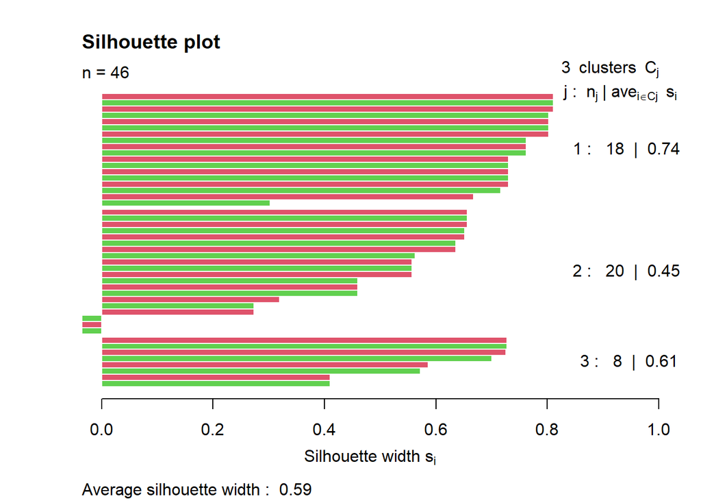

### En mujeres

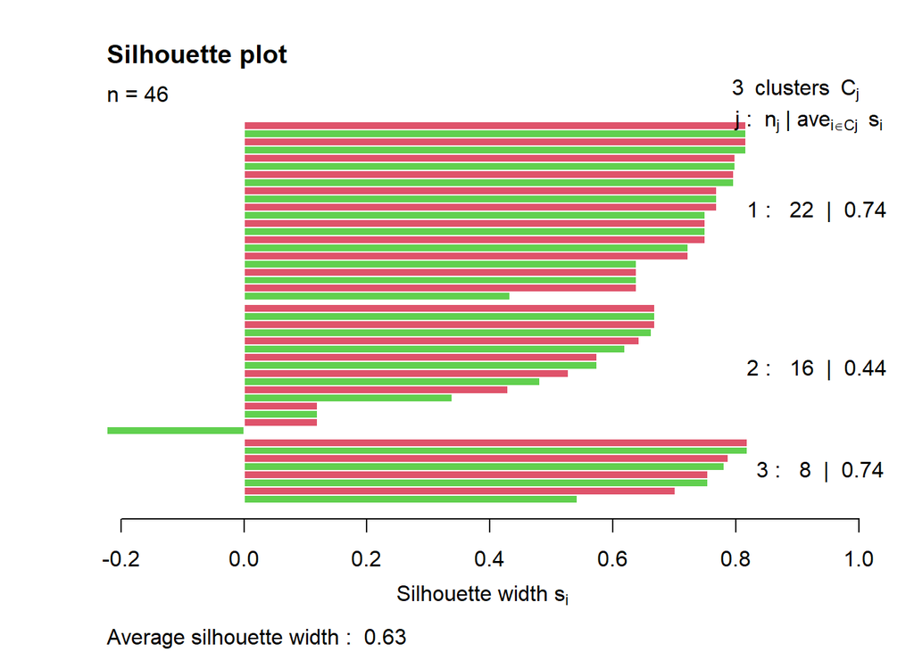

## Conclusiones:

La ley guatemalteca, establece la mayoría de edad, como determinante de la libre aptitud para contraer matrimonio, no obstante, por medio de la simple autorización de los padres, tutores o padres adoptivos en su caso, o un Juez a través de la dispensa judicial, los menores de edad pueden contraer matrimonio civil, a los 16 años los varones, y a los 14 las mujeres. A través de los datos analizados, se han podido observar la gran cantida de matrimonios con ambos o un individuo menores de edad por ende es una realidad que se utiliza de manera recurrente la autorización de los padres para poder contraer matrimonio cuando aún no se ha cumplido la mayoría de edad. Esto no significa que la autorización de los padres sea cien por ciento veridica o no forzada.

Durante la experiencia en el análsis, ha dejado ver muchos casos en los que aunque uno, o los dos contrayentes son menores de edad, han logrado realizar los fines del matrimonio, especialmente en cuanto a permanencia, fidelidad y auxilio mutuo, por lo que no debe negárseles indiscriminadamente su derecho, pero también es cierto, que las épocas han cambiado, y en la actualidad, los matrimonios entre adolescentes son más propensos a la separación, o al divorcio al enfrentar situaciones adversas. Esto conlleva a analizar los posibles matrimonios infantiles y es que este se considera una forma de matrimonio forzoso, ya que no se cuenta con el consentimiento pleno, libre e informado de una de las partes o de ninguna de ellas.

Dentro de la información generada a partir de los datos del INE, sobre los años de las mujeres que han contraido matrimonio de 12 a 25 años de edad se observa que, en la categoría de casadas, los porcentajes más altos se encuentran en las mujeres del rango de 21 a 25 años, de igual manera en la categoría de alguna vez unida o casada, las mujeres en este rango de edad, representan más del 70%. Un 10% de quienes responden que están casadas son niñas y adolescentes del rango de 15 a 17 años, mientras que el 25.4% en esta categoría de casadas pertenece al rango de mujeres de 18 a 20 años. Se destaca que las más jóvenes, adolescentes de 12 a 14 años, representan un 3.5% de la categoría haber estado alguna vez casadas. Estos datos han variado a partir de las reformas impuestas en Reforma el artículo 81 del Código Civil, Decreto Ley 106, artículos: 81, relativo a la aptitud para contraer matrimonio y establece que la edad mínima para contraer matrimonio es de 18 años; 82, relativo a la excepción a la edad mínima y la establece en 16 años, cuando concurran razones fundadas; 84, relativo a la autorización judicial para que los menores de edad puedan contraer matrimonio; 177 en el que prohíbe la unión de menores de edad.Publicada el Lunes, 23 de noviembre del 2015.

#—————————Apartado de predición———————————-

Con el fin de poder investigar más a fondo bajo que criterios es más probable que en un casamiento se encuentre implicada una mujer menor de edad (que en el análisis anterior se evidenció era más recurrente que los hombres) se decidió untilizar ML para poder predecir si dadas ciertas características una mujer será menor de edad en un matrimonio, para poder determinar en que lugares (o situaciones) debe ser atendido este problema.

Con el objetivo de poder estudiar por categorias, se realizará una variable de clasificación adicional en el dataframe para poder llevar a cabo la predicción, en este caso se separó por menores y mayores de edad

A su vez, es necesario convertir todos los datos a factores para poder hacer un análisis con RWEKA

Luego, hacemos los conjuntos de entrenamiento y prueba y se borran las bases de datos de cada año individuales para liberar espacio en la memoria de R

## Segundo análisis de datos

Debido a que al tratar de hacer las predicciones se ha contado con errores debido a la gran cantidad que se está manejando, se ha decidido verificar cuáles son las variables más significativas para trabajar únicamente con ellas, sin embargo, al contar con variables que no son únicamente numéricas no es posible realizar una correlación entre ellas, por lo que se ha estudiado los datos de cada variable y se ha discutido su importancia, llegando a lo siguiente: En el caso de la ocupación, tanto de hombres como mujeres, se cuenta con demasiados valores diferentes por lo que no se considera que sea significativo. En el caso de los hombres se cuenta con 489 diferentes ocupaciones y en el caso de las mujeres se cuenta con 487 ocupaciones diferentes. El número de nupcias también es ignorado ya que los valores de “ignorado” y “none” representan en hombres el 37.0% y el 44.61% respectivamente y en mujeres representa el 37.06% y 44.61% respectivamente, por lo que no se vuelve tan significativo. La variable de escolaridad tanto de hombres como mujeres también será eliminada ya que los valores de ignorado y ninguno representan un 13.35% y 21.89% para los hombres y un 13.06% y 30.68% para las mujeres. Por último, aquellos datos que tengan el registro, como el departamento de ocurrencia o el municipio de ocurrencia, también serán eliminados debido a que es más confiable trabajar con los datos de ocurrencia, porque en muchos casos se registran matrimonios tiempo después de que hayan ocurrido o incluso en lugares diferentes, por lo que los datos de registro no son tan confiables, además, en caso de que sí se haya registrado en la fecha y lugares correctos, se tendría los datos duplicados.

Por lo que nos quedamos con los valores de: Clase de unión, edad del hombre, etnia del hombre y de la mujer, nacionalidad del hombre y mujer, departamento, municipio, mes, año, día y área de ocurrencia y la variable a predecir que es si la mujer es mayor o menor de edad

```r
datosML <- datosML[,c(5,6,7,8,9,10,15,16,17,18,19,22,23)]
porciento <- 70/100
set.seed(123)

trainRowsNumber<-sample(nrow(datosML),porciento*nrow(datosML))
train<-datosML[trainRowsNumber,]
test<-datosML[-trainRowsNumber,]
```

Para poder escoger los grupos de entrenamiento y prueba se ha utilizado el 70% del total de los datos para el entrenamiento y el 30% restante para la prueba, esto para que se cuente con una cantidad significativa de datos para así mejorar el entrenamiento de los mismos sin que se aprendan patrones específicos.

## Prediccion por redes neuronales: RWEKA

Se ha definido el uso de 13 nodos, que representan las 13 columnas a utilizar con los respectivos datos, a partir de esto puede observarse cómo es que se toman cada uno de los valores de las respectivas columnas y todo llega a una variable respuesta, por lo que se cuenta con una capa de entrada, en donde se reciben las señales de entrada, se cuenta con la capa oculta que es la que define la topología de toda la red pero no es posible observar y por último se cuenta con la capa de salida, que recibe la información de la capa oculta para poder transmitir la respuesta obtenida.

```
## An R interface to Weka class
## 'weka.classifiers.functions.MultilayerPerceptron', which has
## information
##
##   A classifier that uses backpropagation to learn a multi-layer
##   perceptron to classify instances. The network can be built by hand or
##   or set up using a simple heuristic. The network parameters can also
##   be monitored and modified during training time. The nodes in this
##   network are all sigmoid (except for when the class is numeric, in
##   which case the output nodes become unthresholded linear units).
##
## Argument list:
##   (formula, data, subset, na.action, control = Weka_control(),
##     options = NULL)
##
## Returns objects inheriting from classes:
##   Weka_classifier
```

[output not shown]

```
## Confusion Matrix and Statistics
##
##           Reference
## Prediction Mayor Menor
##      Mayor 16284  8437
##      Menor     0     0
##
##                Accuracy : 0.6587
##                  95% CI : (0.6528, 0.6646)
##     No Information Rate : 0.6587
##     P-Value [Acc > NIR] : 0.503
##
##                   Kappa : 0
##
##  Mcnemar's Test P-Value : <2e-16
##
##             Sensitivity : 1.0000
##             Specificity : 0.0000
##          Pos Pred Value : 0.6587
##          Neg Pred Value :    NaN
##              Prevalence : 0.6587
##          Detection Rate : 0.6587
##    Detection Prevalence : 1.0000
##       Balanced Accuracy : 0.5000
##
##        'Positive' Class : Mayor
##
```

Utilizando redes neuronales por Rweka se obtuvo un porcentaje de casi 66% en donde, si se observa la matriz de confusión, el algoritmo realmente predijo que todas las mujeres en base a los datos de test serían mayores de edad, situación que evidentemente no sucede, es posible que esto se deba a que los datos no muestran realmente un patrón evidente en el cuál se identifique un set de características para poder diferenciar estos dos grupos.

## Prediccion por medio de árboles de decisión

```
## Confusion Matrix and Statistics
##
##           Reference
## Prediction Mayor Menor
##      Mayor 13703  2953
##      Menor  2581  5484
##
##                Accuracy : 0.7761
##                  95% CI : (0.7709, 0.7813)
##     No Information Rate : 0.6587
##     P-Value [Acc > NIR] : < 2.2e-16
##
##                   Kappa : 0.4968
##
##  Mcnemar's Test P-Value : 6.127e-07
##
##             Sensitivity : 0.8415
##             Specificity : 0.6500
##          Pos Pred Value : 0.8227
##          Neg Pred Value : 0.6800
##              Prevalence : 0.6587
##          Detection Rate : 0.5543
##    Detection Prevalence : 0.6738
##       Balanced Accuracy : 0.7457
##
##        'Positive' Class : Mayor
##
```

## Predicción por medio de Naive Bayes

```
## Confusion Matrix and Statistics
##
##           Reference
## Prediction Mayor Menor
##      Mayor 25632  3999
##      Menor 12267 15783
##
##                Accuracy : 0.718
##                  95% CI : (0.7143, 0.7217)
##     No Information Rate : 0.657
##     P-Value [Acc > NIR] : < 2.2e-16
##
##                   Kappa : 0.4311
##
##  Mcnemar's Test P-Value : < 2.2e-16
##
##             Sensitivity : 0.6763
##             Specificity : 0.7978
##          Pos Pred Value : 0.8650
##          Neg Pred Value : 0.5627
##              Prevalence : 0.6570
##          Detection Rate : 0.4444
##    Detection Prevalence : 0.5137
##       Balanced Accuracy : 0.7371
##
##        'Positive' Class : Mayor
##
```

```
## Confusion Matrix and Statistics
##
##           Reference
## Prediction Mayor Menor
##      Mayor 10941  1784
##      Menor  5343  6653
##
##                Accuracy : 0.7117
##                  95% CI : (0.706, 0.7173)
##     No Information Rate : 0.6587
##     P-Value [Acc > NIR] : < 2.2e-16
##
##                   Kappa : 0.418
##
##  Mcnemar's Test P-Value : < 2.2e-16
##
##             Sensitivity : 0.6719
##             Specificity : 0.7886
##          Pos Pred Value : 0.8598
##          Neg Pred Value : 0.5546
##              Prevalence : 0.6587
##          Detection Rate : 0.4426
##    Detection Prevalence : 0.5147
##       Balanced Accuracy : 0.7302
##
##        'Positive' Class : Mayor
##
```

## Comparación de algoritmos

Según los algoritmos con los que hemos trabajado, que han sido redes neuronales por RWEKA, árboles de decisión y naive bayes, hemos obtenido porcentajes de precisión satisfactorios, sin embargo, hay modelos que logran clasificar mejor que otros. En este caso el modelo que ha logrado una mejor precisión al predecir ha sido el de árboles de decisión con un porcentaje de 78%, seguido de Naive Bayes con un porcentaje de 71% y por último con RWEKA con un porcentaje de 66%.

## Conclusiones

Se ha logrado predecir si la edad de una mujer en un matrimonio supera la mayoría de edad o no la supera, es decir, si es mayor o menor de 18 años.

El alogritmo más efectivo para hacer la predicción ha sido los árboles de decisión por medio de rpart, con un porcentaje de acierto de 78%.

### Bibliografía

Chen, S., Webb, G., Liu, L. & Ma, Xin. (2019). A novel selective Naive Bayes algorithm. Elsevier. https://www.sciencedirect.com/science/article/abs/pii/S0950705119306185

Du, J., Chen, Q., Peng, Y., Xiang, Y., Tao, C, Lu, Z. (2019). ML-Net: Multi-label classification of biomedical texts with deep neural networks. Journal of the american medical informatic Association. 1279-1285. https://doi.org/10.1093/jamia/ocz085

Freund, Y., Mason, L. (2000). The alternating decision tree learning algorithm. http://citeseerx.ist.psu.edu/viewdoc/download?doi=10.1.1.116.2945&rep=rep1&type=pdf

Karim, M. Rahman, R. (2013). Decision tree and Naive Bayes Algorithm for Classification and Generation of Actionable Knowledge for Direct Marketing. https://www.scirp.org/html/6-9301587_30463.htm?pagespeed=noscript

Prensa Libre (2019). https://www.prensalibre.com/guatemala/comunitario/persisten-matrimonios-de-menores-de-edad-en-guatemala-pese-a-prohibicion/

unionestempranas. (s.f.) https://unionestempranas.org/edades-minimas-para-el-matrimonio-en-guatemala/